# *M. cavernosa* transcriptome analysis

# Load data

##### Gene count data

```r
# Import gene expression / count data
counts <- read.table("data/tagseq/processed/counts_newpars.txt",
                     header = TRUE, row.names = 1)
# Trim column names to just the sample name
colnames(counts) <- str_sub(colnames(counts), 1, 7)
# Order columns by sample name
counts <- counts[, order(colnames(counts))]
```

##### Sample metadata

```r
# Import sample metadata
sdat <- read_xlsx("data/sample_metadata.xlsx") %>%
  mutate(sym = recode(trt1, b = "D", c = "C"),
         sample = paste0(species, colony, ".", core),
         group = paste(sym, trt2, sep = ""),
         colony = factor(colony),
         colony.group = interaction(colony, group)) %>%
  mutate_if(is.character, as.factor) %>%
  arrange(sample) %>%                              # order rows by sample name
  column_to_rownames(var = "sample")               # set sample name to rownames
```

##### Gene annotations

```r
trinotate <- readxl::read_xlsx("data/genome/Mcavernosa_trinotate_annotation_report.xlsx",
                                sheet = "Mcavernosa_trinotate_annotation")
```

#### Create DESeqDataSet

```r
# Create full DESeqDataSet
dds <- DESeqDataSetFromMatrix(countData = counts,
                              colData = sdat,
                              design = ~ colony)

# Subset DESeqDataSet
## Subset time point at end of heat stress
dds <- dds[, colData(dds)$date_sampled == "2017-10-28"]
### Remove genes counted zero times in subset
dds <- dds[ rowSums(counts(dds)) > 0, ]

## Subset only the colonies in the heat stress experiment
hs.dds <- dds[, colData(dds)$colony %in% c(20, 22, 26)]
### Remove genes counted zero times in subset
hs.dds <- hs.dds[ rowSums(counts(hs.dds)) > 0, ]
### Drop unused factor levels
colData(hs.dds) <- droplevels(colData(hs.dds))
```

#### Summarize count data

```r
# Read in count totals of raw, postQC, and mapped reads
count_summ <- read.table("data/tagseq/processed/count_totals_newpars.txt") %>%
  mutate(sample_id = str_sub(V1, 3, 7),
         raw = V2, post_qc = V4, mapped = V6) %>%
  select(sample_id, raw, post_qc, mapped) %>%
  gather(stage, count, -sample_id) %>%
  separate(sample_id, into = c("colony", "core"))

# Summarize counts for only samples included in paper (sampled 2017-10-28)
filter(sdat, date_sampled == "2017-10-28") %>%
  left_join(count_summ) %>%
  group_by(stage) %>%
  summarize(`Min. (per sample)` = min(count),
            `Max. (per sample)` = max(count),
            `Median (per sample)` = median(count),
            Total = sum(count)) %>%
  mutate_if(is_numeric, ~ format(ceiling(.), big.mark = ",")) %>%
  arrange(rev(stage)) %>%
  knitr::kable(caption = "Total read counts")
```

Total read counts

| stage | Min. (per sample) | Max. (per sample) | Median (per sample) | Total |
| --- | --- | --- | --- | --- |
| raw | 577,272 | 54,489,606 | 2,569,899 | 177,141,789 |
| post_qc | 317,414 | 4,481,999 | 581,371 | 39,958,845 |
| mapped | 14,339 | 1,230,318 | 82,032 | 5,857,638 |

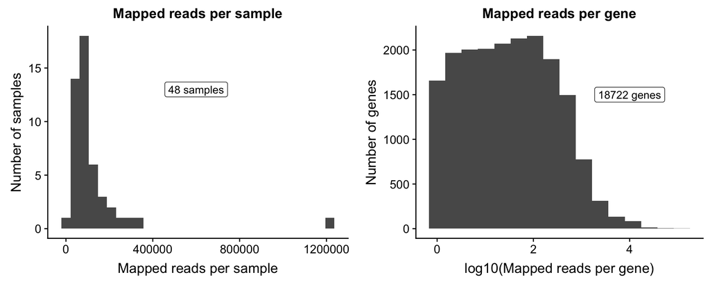

```r
# Number of samples
nsamples <- ncol(counts(dds))

# Number of reads per sample
rps <- qplot(colSums(counts(dds))) +
  labs(x = "Mapped reads per sample", y = "Number of samples",
       title = "Mapped reads per sample") +
  geom_label(aes(x = 6e5, y = 13, label = paste(nsamples, "samples")))
# Sample Mc20-05 has far more counts than others -- may need to rarefy this sample down to median count?

# Number of reads per colony
# count_summ %>%
#   filter(stage == "mapped", colony %in% c(20,22, 26)) %>%
#   group_by(colony) %>%
#   ggplot(aes(x = colony, y = count)) +
#   geom_boxplot() +
#   ylim(0, 300000)

# Number of genes
ngenes <- nrow(counts(dds))
# Number of reads per gene
rpg <- qplot(log10(rowSums(counts(dds))), bins = 16) +
  labs(x = "log10(Mapped reads per gene)", y = "Number of genes",
       title = "Mapped reads per gene") +
  geom_label(aes(x = 4, y = 1500, label = paste(ngenes, "genes")))

plot_grid(rps, rpg)
```

#### Filter and transform count data

```r
# Filter out sample that did not shuffle -- Mc22.12 (17th sample in hs.dds)
hs.dds <- hs.dds[, -17]

# Remove genes with less than 2 mean count across samples
hs.dds <- hs.dds[ rowMeans(counts(hs.dds)) > 1, ]

# Normalize expression data for visualization purposes using VST tranformation
vsd <- vst(hs.dds, blind = TRUE)
```

# Visualize global gene expression

#### Principal Coordinate Analysis (PCoA)

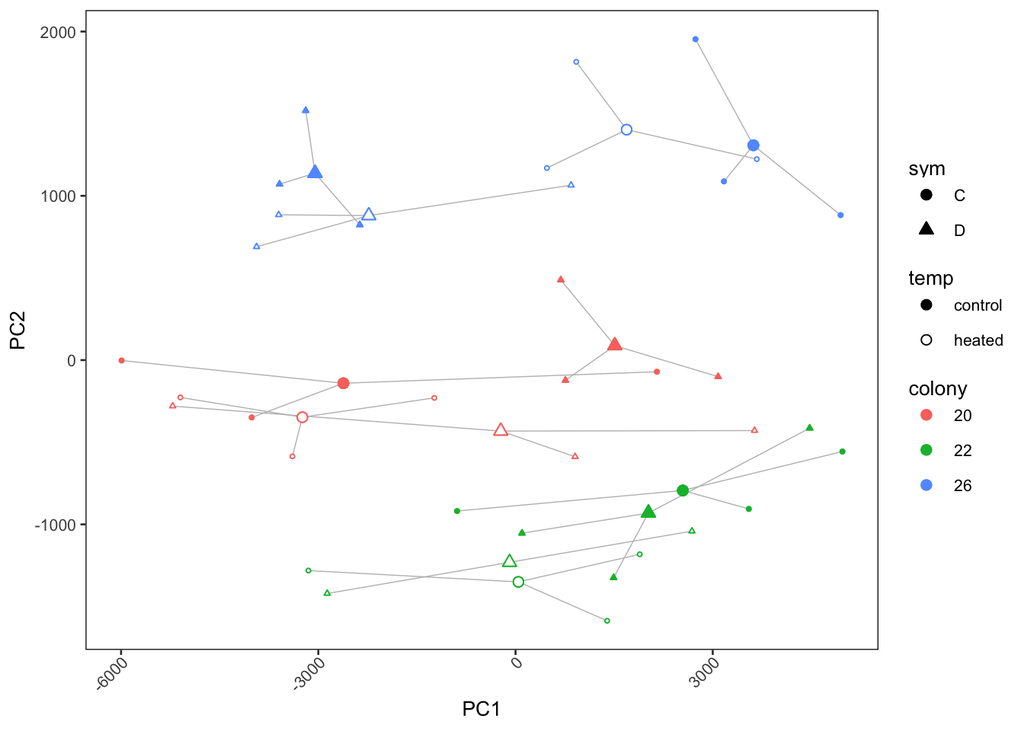

```r
## Calculate distances among samples
sampleDists <- dist(t(assay(vsd)), method = "manhattan")
sampleDistMatrix <- as.matrix(sampleDists)

## Calculate MDS
mds <- as.data.frame(colData(vsd)) %>%
  cbind(cmdscale(sampleDistMatrix)) %>%
  mutate(fillcol = factor(ifelse(trt2 == "h", NA, colony))) %>%    # create factor for fill color in plot
  mutate(alphaval = ifelse(trt2 == "h", 1, 0))

# Calculate group centroids for plotting
mds <- mds %>%
  group_by(colony, sym, trt2) %>%
  dplyr::summarise(c1 = mean(`1`), c2 = mean(`2`)) %>%
  full_join(mds)

# Plot with spiders
pcoa <- ggplot(mds, aes(color = colony, shape = sym)) +
  geom_segment(mapping = aes(x = `1`, y = `2`, xend = c1, yend = c2),
               lwd = 0.25, col = "grey") +
  geom_point(size = 2, aes(x = c1, y = c2, fill = colony, alpha = as.character(alphaval))) +
  geom_point(size = 2, aes(x = c1, y = c2), fill = ifelse(mds$alphaval, "white", NA)) +
  geom_point(size = 0.7, aes(x = `1`, y = `2`, fill = colony, alpha = as.character(alphaval)), show.legend = F) +
  geom_point(size = 0.7, aes(x = `1`, y = `2`), fill = ifelse(mds$alphaval, "white", NA), show.legend = F) +
  scale_shape_manual(values = c(21, 24)) +
  scale_alpha_manual(values = c(1, 0), name = "temp", labels = c("control", "heated")) +
  guides(shape = guide_legend(order = 2, override.aes = list(fill = "black"))) +
  guides(alpha = guide_legend(override.aes = list(shape = 21, alpha = 1, fill = c("black", "white")))) +
  labs(x = "PC1", y = "PC2") +
  theme_custom() +
  theme(legend.spacing.y = unit(0, "cm"))

pcoa
```

```r
ggsave(filename = "output/pcoa.png", pcoa, width = 109, height = 84.5, units = "mm")
```

# Variance partitioning

Partition total transcriptome variance among explanatory factors (symbiont, heating, and their interaction) for each colony. Based on the PCoA above, it appears that symbiont type should explain the most variance in colony 26, and very little variance in colony 22. Heating should explain more variance in colony 22.

```r
# Get sample data for heat stress experiment into tibble
coldata <- sdat %>%
  rownames_to_column("sample") %>%
  as_tibble() %>%
  select(sample, colony, sym, trt2, date_sampled, group) %>%
  filter(sample != "Mc22.12")   # Exclude sample that did not shuffle symbionts
# Gather raw counts into tibble
colcounts <- counts %>%
  rownames_to_column("gene") %>%
  as_tibble() %>%
  gather(key = "sample", value = "count", -gene)
# Join count data with sample data, and nest vs count data by colony
all <- left_join(coldata, colcounts) %>%
  filter(colony %in% c(20, 22, 26), date_sampled == "2017-10-28") %>%
  nest(-colony)

# Create DESeqDataSet for each colony, filter genes mean count > 1 within each colony, and vst transform
all <- all %>%
  mutate(sdat = map(data, ~ data.frame(column_to_rownames(distinct(., sample, sym, trt2, group), "sample"))),
         counts = map(data, ~ spread(select(., sample, gene, count), sample, count)),
         counts = map(counts, ~ as.matrix(column_to_rownames(., "gene"))),
         dds = map2(counts, sdat, ~ DESeqDataSetFromMatrix(countData = .x, colData = .y, design = ~ group)),
         ddsf = map(dds, function(x) x[rowMedians(counts(x)) > 1, ]),  # Filter DESeqDataSet
         vsd = map(ddsf, ~ vst(., blind = FALSE)))  # Variance Stabilizing Transformation

# Run variance partition analysis for each colony
cl <- makeCluster(8); registerDoParallel(cl)
all <- all %>%
  mutate(vp = map2(vsd, sdat, ~ fitExtractVarPartModel(
    exprObj = assay(.x), data = .y, formula = ~ (1|sym) + (1|trt2) + (1|sym:trt2)
    )))
stopCluster(cl)

# Calculate sum of variance explained by each source across all genes for each colony
all <- all %>% mutate(vpsum = map(vp, ~ summarise_all(., sum)))
```

Plot sources of variance for each colony

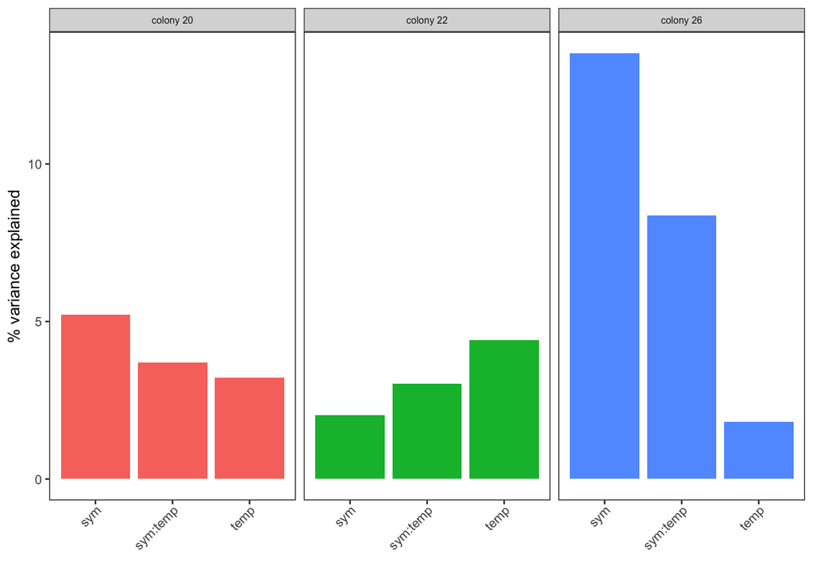

```r
varpartfig <- all %>%
  unnest(vpsum, .drop = T) %>%
  gather(source, value, -colony) %>%
  group_by(colony) %>%
  mutate(relvar = value / sum(value)) %>%   # TOTAL VARIANCE NOT SAME FOR EACH COLONY -- NORMALIZE WITHIN COLONY
  filter(source != "Residuals") %>%
  mutate(source = recode(source, trt2 = "temp", `sym:trt2` = "sym:temp")) %>%
  ggplot(aes(x = source, y = relvar*100, fill = colony)) +
  geom_bar(stat = "identity") +
  facet_wrap(~ colony, labeller = global_labeller) +
  labs(x = "", y = "% variance explained") +
  theme_custom() +
  theme(legend.position = "none",
        strip.text.x = element_text(size = 6))

varpartfig
```

```r
save(varpartfig, file = "output/varpartfig.RData")

ggsave(filename = "output/varpart.png", plot = varpartfig, width = 69, height = 84.5, units = "mm")

fig2 <- cowplot::plot_grid(pcoa, varpartfig, rel_widths = c(2, 1), labels = "AUTO")
ggsave(filename = "figures/fig2.png", fig2, width = 169, height = 84.5, units = "mm")


all %>%
  unnest(vpsum, .drop = T) %>%
  gather(source, value, -colony) %>%
  group_by(colony) %>%
  mutate(relvar = value / sum(value)) %>%   # TOTAL VARIANCE NOT SAME FOR EACH COLONY -- NORMALIZE WITHIN COLONY
  filter(source != "Residuals") %>%
  summarise(total_explained = sum(relvar))
```

```
## # A tibble: 3 x 2
##   colony total_explained
##   <fct>            <dbl>
## 1 20              0.121
## 2 22              0.0947
## 3 26              0.237
```

#### Discriminant analysis of principal components (DAPC)

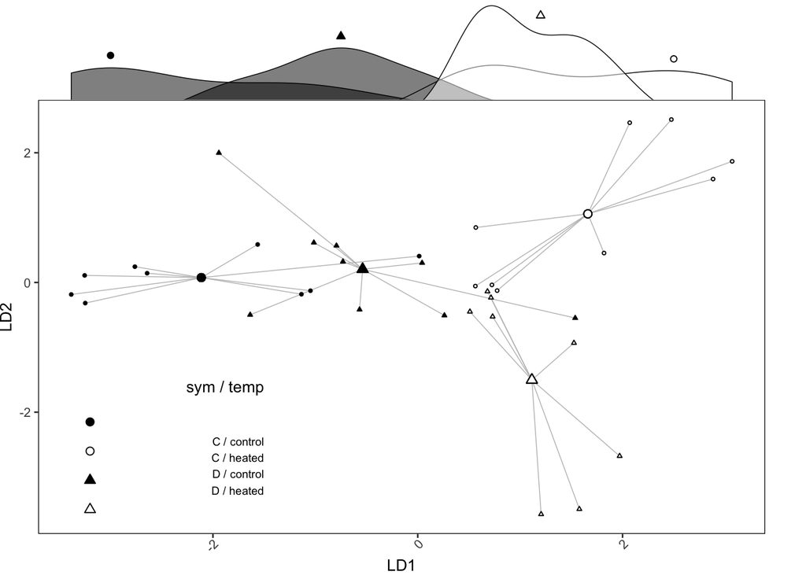

```r
# Discriminant function including all genes
vsd2 <- limma::removeBatchEffect(assay(vsd), vsd$colony)
# use batch-colony-removed vst counts
dat <- data.frame(vsd2)
# use regular vst counts
#dat <- data.frame(assay(vsd))

# How many PCs should be kept?
# dapc2 <- dapc(t(dat), colData(hs.dds)$group, n.da=4, n.pca=35)
# temp <- optim.a.score(dapc2, n.sim = 5)
# my.dapc <- function(n.pca) dapc(t(dat), colData(hs.dds)$group, n.pca = n.pca, n.da = 4)

# library(furrr)
# plan(multiprocess)
# my.dapc.res <- tibble(n.pca = 5:20) %>%
#   mutate(dapc = map(n.pca, my.dapc),
#          a.score = furrr::future_map(dapc, a.score, n.sim = 1000),
#          mean = map_dbl(a.score, ~ .$mean),
#          cumvar = map_dbl(dapc, ~ .$var))
#
# my.dapc.res %>%
#   arrange(-mean) %>%
#   head()

# Retaining 6 PC's gives highest a-score (25%), but only utilizes 44% of variance. Retaining 15 PC's reduces a-score to 17%, but retains 72% of variance. Therefore, let's use 15 PC's for the DA.

dp1 <- dapc(t(dat), colData(hs.dds)$group,
            n.pca = 15, n.da = 2)   # Retain 15 PCs and 2 discriminant functions
#scatter(dp1,bg="white",scree.da=TRUE,scree.pca=TRUE,legend=TRUE,solid=.4)

# Axis one represents general heat stress response, and effect of D under control moving toward this transcriptional state.  Axis two represents the *different/unique* heat stress responses of C vs. D corals.

#scatter(dp1, bg = "white", legend = TRUE, scree.da = FALSE)

dapc <- tibble(sample = rownames(dp1$ind.coord),
               grp = dp1$grp,
               LD1 = dp1$ind.coord[,1],
               LD2 = dp1$ind.coord[,2])
dapc <- dapc %>%
  group_by(grp) %>%
  summarize(c1 = mean(LD1),
            c2 = mean(LD2)) %>%
  full_join(dapc)

# Plot with spiders
dapc.fig <-
  ggplot(dapc, aes(shape = factor(grepl("^D", grp)),
                             fill = factor(grepl("h", grp)))) +
  geom_segment(mapping = aes(x = LD1, y = LD2, xend = c1, yend = c2), lwd = 0.25, col = "grey") +
  geom_point(aes(x = c1, y = c2), size = 2) +
  geom_point(aes(x = LD1, y = LD2), size = 0.7, show.legend = FALSE) +
  scale_shape_manual(name = "sym", labels = c("C", "D"), values = c(21, 24)) +
  scale_fill_manual(name = "temp", labels = c("control", "heated"), values = c("black", "white")) +
  guides(fill = guide_legend(override.aes = list(shape = 21, size = 2))) +
  guides(shape = guide_legend(override.aes = list(fill = "black", size = 2))) +
  labs(x = "LD1", y = "LD2") +
  theme_custom() +
  #theme(legend.position = c(0.25, 0.15)) +
  theme(plot.margin = margin(t = 0, r = 0.9, unit = "cm")) +
  #theme(legend.spacing.y = unit(0, "cm"),
  #      legend.spacing.x = unit(0, "cm")) +
  #theme(legend.box = "horizontal") +
  theme(legend.position = "none") +
  annotate(geom = "text", x = -1.5, y = -1.6, adj = 1, label = "sym / temp", size = 3.5) +
  annotate(geom = "text", x = -1.5, y = -2.825, adj = 1, size = 2.5,
           label = "C / control\nC / heated\nD / control\nD / heated") +
  annotate(geom = "point", x = -3.2, y = seq(from = -2.15, by = -0.45, length.out = 4),
           size = 2, shape = c(21, 21, 24, 24), fill = c("black", "white", "black", "white"))

xplot <-
  ggdensity(dapc, x = "LD1", fill = "grp", lwd = 0.25,
            palette = c("black", "white", "black", "white")) +
  annotate(geom = "point", x = c(-3,-0.75, 1.2, 2.5), y = c(0.37,0.48,0.6,0.35),
           pch = c(21, 24, 24, 21), fill = c("black", "black", "white", "white")) +
  clean_theme() + rremove("legend") +
  theme(plot.margin = unit(c(0, 0, 0, 0), "cm"))

#ggplot(dapc, aes(x = LD1, fill = grp)) + geom_density(alpha = 0.5, adjust = 1)

fig3 <- plot_grid(xplot, NULL, dapc.fig, ncol = 1, align = "hv", rel_heights = c(0.7, -0.28, 2))
fig3
```

```r
ggsave(filename = "figures/fig3.png", plot = fig3, width = 80, height = 80, units = "mm")
```

The DAPC shows that despite the significant variability among colonies, the four treatment groups can be discriminated well based on gene expression data. The first discriminant function (x-axis) represents the effect of heat stress in general, with control temperature corals to the left and heated corals to the right. Along this axis, D-control corals are intermediate between C-control corals and heated corals, showing that the presence of D shifts the transcriptional state toward the heat-stressed state. The second discriminant function (y-axis) separates the distinct responses to heat stress that occur in C vs. D corals.

# Differential expression (DE) analysis

Since colonies appear to respond differently to symbiont type and heating, we should analyze differential expression in each colony separately to assess their unique responses. We can also analyze differential expression across all colonies together to see what responses are common to all three.

##### Run DESeq analysis

First, within each colony

```r
# Run DESeq pipeline
design(hs.dds) <- formula(~ colony.group)
dsr1 <- DESeq(hs.dds)

# Define group contrasts
group.contrasts <- tibble(num = c("Dh", "Dh", "Dh", "Dc", "Dc", "Ch"),
                          den = c("Dc", "Ch", "Cc", "Ch", "Cc", "Cc"))

# Get DESeq results for all group contrasts for each colony
DE <- crossing(colony = c("20", "22", "26"), group.contrasts) %>%
  mutate(dsr = pmap(list(colony, num, den), function(x, y, z) {
    results(dsr1, contrast = c("colony.group", paste0(x, ".", c(y, z))))}))
```

Then, for all colonies together

```r
# Run DESeq pipeline
design(hs.dds) <- formula(~ colony + group)
dsr2 <- DESeq(hs.dds)

# Get DESeq results for all contrasts and join with results from each colony, from above
DE <- crossing(colony = "all", group.contrasts) %>%
  mutate(dsr = map2(num, den, ~ results(dsr2, contrast = c("group", .x, .y)))) %>%
  bind_rows(DE)
```

##### Get significantely DE genes

```r
DE <- DE %>%
  mutate(sig = map(dsr, ~ rownames_to_column(data.frame(.[which(.$padj < 0.1), ]), "gene")),
          up = map(sig, ~ filter(., log2FoldChange > 0)),
        down = map(sig, ~ filter(., log2FoldChange < 0)))

# Generate logP values for all differential expression contrasts
DE <- DE %>% mutate(logP = map(dsr, ~ data.frame(
  gene = rownames(data.frame(.)),
  logP = -log10(data.frame(.)$pvalue) * sign(data.frame(.)$log2FoldChange))))

# Count number of differentially expressed genes within each colony, and overall, for each contrast
DEtab <- DE %>%
  mutate(nsig = map_dbl( sig, ~ nrow(.)),
          nup = map_dbl(  up, ~ nrow(.)),
          ndn = map_dbl(down, ~ nrow(.)),
          `DEGs [up, down]` = paste0(nsig, " [", nup, ", ", ndn, "]")) %>%
  select(colony, num, den, `DEGs [up, down]`) %>%
  spread(colony, `DEGs [up, down]`) %>%
  knitr::kable(caption = "Number of differentially expressed genes within individual colonies and across all colonies for each specified contrast. DEGs identified using DESeq with an adjusted p-value < 0.1. In brackets are the numbers of significantly up- and down-regulated genes.")

DEtab
```

Number of differentially expressed genes within individual colonies and across all colonies for each specified contrast. DEGs identified using DESeq with an adjusted p-value < 0.1. In brackets are the numbers of significantly up- and down-regulated genes.

| num | den | 20 | 22 | 26 | all |
| --- | --- | --- | --- | --- | --- |
| Ch | Cc | 9 [2, 7] | 28 [12, 16] | 277 [166, 111] | 80 [37, 43] |
| Dc | Cc | 33 [6, 27] | 58 [22, 36] | 688 [495, 193] | 30 [10, 20] |
| Dh | Ch | 4 [3, 1] | 9 [5, 4] | 36 [24, 12] | 0 [0, 0] |
| Dh | Dc | 55 [43, 12] | 35 [21, 14] | 2 [1, 1] | 29 [21, 8] |

##### Assess similarity of responses across colonies

```r
DE %>%
  unnest(sig) %>%
  filter(colony != "all") %>%
  group_by(num, den) %>%
  count(gene, log2FoldChange > 0) %>%   # In how many colonies is same gene DE in same direction?
  summarise(`1 colony` = sum(n==1), `2 colonies` = sum(n==2), `3 colonies` = sum(n==3)) %>%
  knitr::kable(caption = "Number of differentially expressed genes in common")
```

Number of differentially expressed genes in common

| num | den | 1 colony | 2 colonies | 3 colonies |
| --- | --- | --- | --- | --- |
| Ch | Cc | 296 | 9 | 0 |
| Dc | Cc | 767 | 6 | 0 |
| Dh | Ch | 43 | 3 | 0 |
| Dh | Dc | 86 | 3 | 0 |

In terms of the specific genes differentially expressed, each colony shows a very different response. There are ZERO differentially expressed genes in common across all three colonies when analyzed individually. However, we still find some differentially expressed genes in common when the colonies are analyzed together, likely due to higher statistical power.

# Gene Ontology enrichment analysis

### D-control vs. C-control

```r
setwd("code/GO_MWU")

# Write all-colony D-control vs. C-control logP values to file for GO_MWU analysis
DE %>%
  filter(colony == "all", num == "Dc", den == "Cc") %>%
  unnest(logP) %>%
  select(gene, logP) %>%
  write.table(., file = "Dctrl.Cctrl.logP.txt", row.names = FALSE, quote = FALSE, sep = ",")

# Run GO_MWU for all-colony D-control vs. C-contol for Biological Process (BP) GO terms
commandArgs <- function(...) c("Dctrl.Cctrl.logP.txt", "BP")
source("GO_MWU.R")
```

```
## Continuous measure of interest: will perform MWU test
## 15  GO terms at 10% FDR
```

```r
# Run GO_MWU for all-colony D-control vs. C-contol for Molecular Function GO terms
commandArgs <- function(...) c("Dctrl.Cctrl.logP.txt", "MF")
source("GO_MWU.R")
```

```
## Continuous measure of interest: will perform MWU test
## 6  GO terms at 10% FDR
```

```r
# Run GO_MWU for all-colony D-control vs. C-contol for Cellular Component (CC) GO terms
commandArgs <- function(...) c("Dctrl.Cctrl.logP.txt", "CC")
source("GO_MWU.R")
```

```
## Continuous measure of interest: will perform MWU test
## 9  GO terms at 10% FDR
```

```r
Dctrl.Cctrl.GO <- as.list(
  c(BP = "code/GO_MWU/MWU_BP_Dctrl.Cctrl.logP.txt",
    MF = "code/GO_MWU/MWU_MF_Dctrl.Cctrl.logP.txt",
    CC = "code/GO_MWU/MWU_CC_Dctrl.Cctrl.logP.txt")
  ) %>% map(read.table, header = T) %>%
  bind_rows(.id = "ontology") %>%
  as_tibble() %>%
  filter(p.adj < 0.01)

Dctrl.Cctrl.GO %>%
  select(ontology, delta.rank, name, p.adj) %>%
  arrange(ontology, delta.rank) %>%
  knitr::kable()
```

| ontology | delta.rank | name | p.adj |
| --- | --- | --- | --- |
| BP | 254 | mRNA metabolic process | 0.0048821 |
| BP | 393 | protein localization to membrane | 0.0035124 |
| BP | 420 | RNA catabolic process | 0.0048821 |
| BP | 428 | cellular component disassembly | 0.0009385 |
| BP | 464 | translational elongation | 0.0010874 |
| BP | 486 | protein targeting to membrane | 0.0007407 |
| BP | 660 | translational initiation | 0.0000004 |
| BP | 670 | protein-containing complex disassembly | 0.0000014 |
| BP | 696 | spindle elongation | 0.0000150 |
| CC | 425 | ribosome | 0.0000463 |
| CC | 425 | cytosolic part | 0.0000463 |
| CC | 468 | large ribosomal subunit | 0.0022966 |
| CC | 622 | cytosolic ribosome | 0.0000001 |
| CC | 677 | cytosolic small ribosomal subunit | 0.0022966 |
| MF | 487 | structural constituent of ribosome | 0.0000155 |

### C-heat vs. C-control

```r
setwd("code/GO_MWU")

# Write all-colony C-heat vs. C-control logP values to file for GO_MWU analysis
DE %>%
  filter(colony == "all", num == "Ch", den == "Cc") %>%
  unnest(logP) %>%
  select(gene, logP) %>%
  write.table(., file = "Cheat.Cctrl.logP.txt", row.names = FALSE, quote = FALSE, sep = ",")

# Run GO_MWU for all-colony C-heat vs. C-contol for Biological Process (BP) GO terms
commandArgs <- function(...) c("Cheat.Cctrl.logP.txt", "BP")
source("GO_MWU.R")
```

```
## Continuous measure of interest: will perform MWU test
## 33  GO terms at 10% FDR
```

```r
# Run GO_MWU for all-colony C-heat vs. C-contol for Molecular Function GO terms
commandArgs <- function(...) c("Cheat.Cctrl.logP.txt", "MF")
source("GO_MWU.R")
```

```
## Continuous measure of interest: will perform MWU test
## 17  GO terms at 10% FDR
```

```r
# Run GO_MWU for all-colony C-heat vs. C-contol for Cellular Component (CC) GO terms
commandArgs <- function(...) c("Cheat.Cctrl.logP.txt", "CC")
source("GO_MWU.R")
```

```
## Continuous measure of interest: will perform MWU test
## 5  GO terms at 10% FDR
```

```r
Cheat.Cctrl.GO <- as.list(
  c(BP = "code/GO_MWU/MWU_BP_Cheat.Cctrl.logP.txt",
    MF = "code/GO_MWU/MWU_MF_Cheat.Cctrl.logP.txt",
    CC = "code/GO_MWU/MWU_CC_Cheat.Cctrl.logP.txt")
  ) %>% map(read.table, header = T) %>%
  bind_rows(.id = "ontology") %>%
  as_tibble() %>%
  filter(p.adj < 0.01)

Cheat.Cctrl.GO %>%
  select(ontology, delta.rank, name, p.adj) %>%
  arrange(ontology, delta.rank) %>%
  knitr::kable()
```

| ontology | delta.rank | name | p.adj |
| --- | --- | --- | --- |
| BP | -713 | ammonium transport | 0.0094110 |
| BP | -622 | sodium ion transport | 0.0094110 |
| BP | -432 | anion transport | 0.0039258 |
| BP | 238 | intracellular signal transduction | 0.0067086 |
| BP | 256 | mRNA metabolic process | 0.0062611 |
| BP | 273 | positive regulation of catalytic activity | 0.0039045 |
| BP | 274 | regulation of transferase activity | 0.0081854 |
| BP | 440 | protein localization to membrane | 0.0017478 |
| BP | 475 | protein targeting to membrane | 0.0026238 |
| BP | 490 | protein-containing complex disassembly | 0.0045161 |
| CC | 226 | ribonucleoprotein complex | 0.0009429 |
| CC | 353 | ribosome | 0.0024924 |
| CC | 392 | cytosolic part | 0.0004238 |
| CC | 494 | cytosolic ribosome | 0.0001344 |
| MF | -519 | secondary active transmembrane transporter activity | 0.0007211 |
| MF | -506 | sodium ion transmembrane transporter activity | 0.0091040 |
| MF | -442 | organic anion transmembrane transporter activity | 0.0043506 |
| MF | -427 | anion transmembrane transporter activity | 0.0012722 |
| MF | 232 | RNA binding | 0.0012722 |
| MF | 422 | structural constituent of ribosome | 0.0007211 |

### D-heat vs. D-control

```r
setwd("code/GO_MWU")

# Write all-colony D-heat vs. D-control logP values to file for GO_MWU analysis
DE %>%
  filter(colony == "all", num == "Dh", den == "Dc") %>%
  unnest(logP) %>%
  select(gene, logP) %>%
  write.table(., file = "Dheat.Dctrl.logP.txt", row.names = FALSE, quote = FALSE, sep = ",")

# Run GO_MWU for all-colony D-heat vs. D-contol for Biological Process (BP) GO terms
commandArgs <- function(...) c("Dheat.Dctrl.logP.txt", "BP")
source("GO_MWU.R")
```

```
## Continuous measure of interest: will perform MWU test
## 3  GO terms at 10% FDR
```

```r
# Run GO_MWU for all-colony D-heat vs. D-contol for Molecular Function GO terms
commandArgs <- function(...) c("Dheat.Dctrl.logP.txt", "MF")
source("GO_MWU.R")
```

```
## Continuous measure of interest: will perform MWU test
## 12  GO terms at 10% FDR
```

```r
# Run GO_MWU for all-colony D-heat vs. D-contol for Cellular Component (CC) GO terms
commandArgs <- function(...) c("Dheat.Dctrl.logP.txt", "CC")
source("GO_MWU.R")
```

```
## Continuous measure of interest: will perform MWU test
## 5  GO terms at 10% FDR
```

```r
Dheat.Dctrl.GO <- as.list(
  c(BP = "code/GO_MWU/MWU_BP_Dheat.Dctrl.logP.txt",
    MF = "code/GO_MWU/MWU_MF_Dheat.Dctrl.logP.txt",
    CC = "code/GO_MWU/MWU_CC_Dheat.Dctrl.logP.txt")
  ) %>% map(read.table, header = T) %>%
  bind_rows(.id = "ontology") %>%
  as_tibble() %>%
  filter(p.adj < 0.01)

Dheat.Dctrl.GO %>%
  select(ontology, delta.rank, name, p.adj) %>%
  arrange(ontology, delta.rank) %>%
  knitr::kable()
```

| ontology | delta.rank | name | p.adj |
| --- | --- | --- | --- |
| BP | -544 | translational initiation | 0.0003707 |
| CC | -420 | cytosolic ribosome | 0.0061805 |
| MF | -472 | organic anion transmembrane transporter activity | 0.0024580 |
| MF | -396 | structural constituent of ribosome | 0.0024580 |
| MF | 515 | molecular adaptor activity | 0.0024580 |
| MF | 647 | signaling adaptor activity | 0.0026139 |

### C-heat vs. D-heat

```r
setwd("code/GO_MWU")

# Write all-colony D-heat vs. C-heat logP values to file for GO_MWU analysis
DE %>%
  filter(colony == "all", num == "Dh", den == "Ch") %>%
  unnest(logP) %>%
  select(gene, logP) %>%
  write.table(., file = "Dheat.Cheat.logP.txt", row.names = FALSE, quote = FALSE, sep = ",")

# Run GO_MWU for all-colony D-heat vs. C-heat for Biological Process (BP) GO terms
commandArgs <- function(...) c("Dheat.Cheat.logP.txt", "BP")
source("GO_MWU.R")
```

```
## Continuous measure of interest: will perform MWU test
## 0  GO terms at 10% FDR
```

```r
# Run GO_MWU for all-colony D-heat vs. C-heat for Molecular Function GO terms
commandArgs <- function(...) c("Dheat.Cheat.logP.txt", "MF")
source("GO_MWU.R")
```

```
## Continuous measure of interest: will perform MWU test
## 0  GO terms at 10% FDR
```

```r
# Run GO_MWU for all-colony D-heat vs. C-heat for Cellular Component (CC) GO terms
commandArgs <- function(...) c("Dheat.Cheat.logP.txt", "CC")
source("GO_MWU.R")
```

```
## Continuous measure of interest: will perform MWU test
## 0  GO terms at 10% FDR
```

```r
Dheat.Cheat.GO <- as.list(
  c(BP = "code/GO_MWU/MWU_BP_Dheat.Cheat.logP.txt",
    MF = "code/GO_MWU/MWU_MF_Dheat.Cheat.logP.txt",
    CC = "code/GO_MWU/MWU_CC_Dheat.Cheat.logP.txt")
  ) %>% map(read.table, header = T) %>%
  bind_rows(.id = "ontology") %>%
  as_tibble() %>%
  filter(p.adj < 0.01)

Dheat.Cheat.GO %>%
  select(ontology, delta.rank, name, p.adj) %>%
  arrange(ontology, delta.rank) %>%
  knitr::kable()
```

| ontology | delta.rank | name | p.adj |
| --- | --- | --- | --- |

Supplemental table with all GO results

```r
allGO <- bind_rows(.id = "contrast",
  Dctrl.Cctrl = Dctrl.Cctrl.GO,
  Cheat.Cctrl = Cheat.Cctrl.GO,
  Dheat.Dctrl = Dheat.Dctrl.GO,
  Dheat.Cheat = Dheat.Cheat.GO
) %>%
  select(contrast, ontology, delta.rank, name, p.adj) %>%
  arrange(contrast, ontology, sign(delta.rank), p.adj)

write_csv(allGO, path = "output/allGO.csv")
```

# EuKaryotic Orthologous Groups (KOG) enrichment analysis

Using the signed log(p-values) from the differential expression analysis, we can analyze which KOG classifications are up- or down-regulated within each colony, and across all three colonies together.

```r
# Import KOG annotations for Mcavernosa genome # Downloaded from M. Studivan github
gene2kog <- read.table("data/genome/Mcavernosa_iso2kog.tab", sep = "\t") %>%
   filter(!V2 == "")

# Run KOG.MWU analysis on all contrasts
KOG <- DE %>%
  mutate(KOG = map(logP, ~ kog.mwu(., gene2kog)),
         # If a KOG term has <10 genes associated with it, set delta rank to zero
         KOG = map(KOG, ~ mutate(., delta.rank = ifelse(nseqs < 10, 0, delta.rank))))

# Generate all KOG delta rank tables
kogtables <- KOG %>%
  unnest(KOG) %>%
  select(colony, num, den, term, delta.rank) %>%
  split(list(.$num, .$den), drop = TRUE) %>%
  map(~ spread(., colony, delta.rank)) %>%
  map(~ column_to_rownames(select(., -num, -den), "term"))

# Generate KOG p-value stars
kogpvals <- KOG %>%
  unnest(KOG) %>%
  select(colony, num, den, term, padj) %>%
  split(list(.$num, .$den), drop = TRUE) %>%
  map(~ spread(., colony, padj)) %>%
  map(~ column_to_rownames(select(., -num, -den), "term")) %>%
  map(~ transmute_all(., gtools::stars.pval))
```

##### Plot KOG results for each colony for each contrast

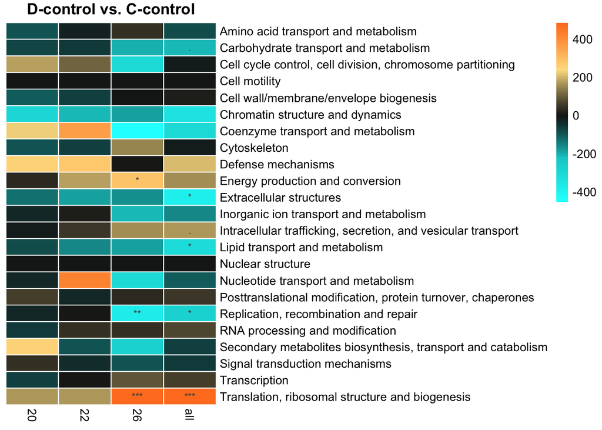

```r
# Function to plot KOG delta ranks heatmap
KOGheatmap <- function(deltaranks, pvals, ...) {
  deltaranks <- as.matrix(deltaranks)
  paletteLength <- 100
  myColor <- colorRampPalette(rev(c("chocolate1","#FEE090","grey10", "cyan3","cyan")))(paletteLength)
  myBreaks <- c(seq(min(deltaranks), 0, length.out = ceiling(paletteLength/2) + 1),
                seq(max(deltaranks)/paletteLength, max(deltaranks),
                    length.out = floor(paletteLength/2)))
  pheatmap(mat = deltaranks, display_numbers = pvals,
           cluster_cols = FALSE, cluster_rows = FALSE,
           treeheight_row = 15, treeheight_col = 15,
           border_color = "white", scale = "none",
           color = myColor, breaks = myBreaks, ...)
}

KOGheatmap(kogtables$Dc.Cc, kogpvals$Dc.Cc, main = "D-control vs. C-control")
```

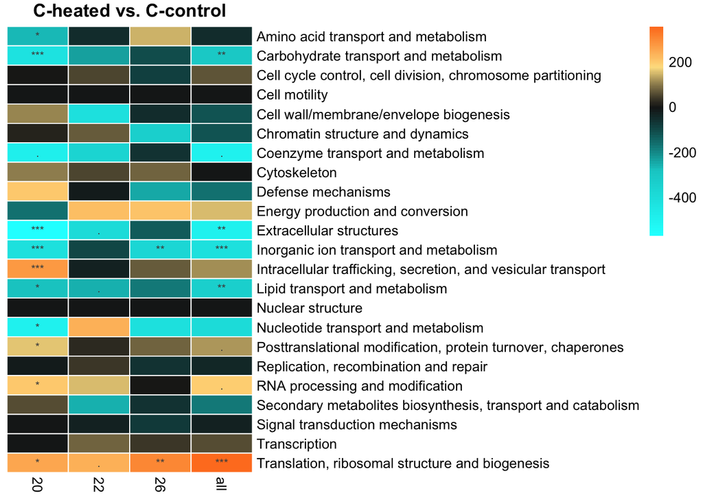

```r
KOGheatmap(kogtables$Ch.Cc, kogpvals$Ch.Cc, main = "C-heated vs. C-control")
```

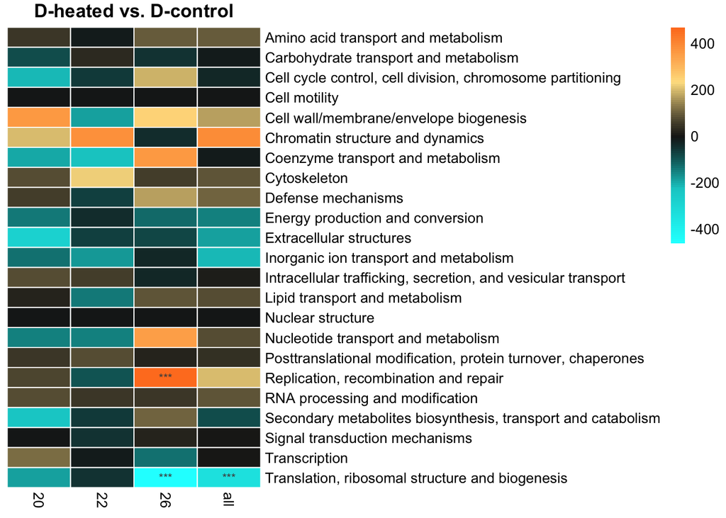

```r
KOGheatmap(kogtables$Dh.Dc, kogpvals$Dh.Dc, main = "D-heated vs. D-control")
```

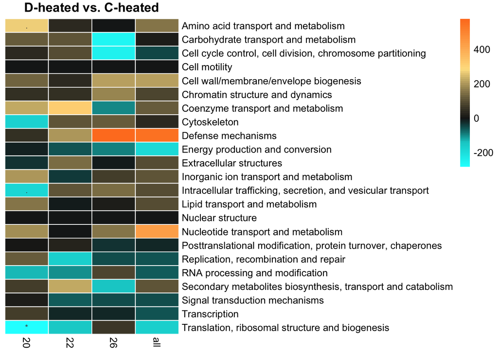

```r
KOGheatmap(kogtables$Dh.Ch, kogpvals$Dh.Ch, main = "D-heated vs. C-heated")
```

##### Plot cross-colony KOG results for each contrast

[figure not shown]

```r
kogtable2 <- KOG %>%
  unnest(KOG) %>%
  filter(colony == "all") %>%
  select(num, den, term, delta.rank) %>%
  unite("contrast", num, den, sep = ".") %>%
  spread(contrast, delta.rank) %>%
  #select(term, Ch.Cc, Dc.Cc, Dh.Dc, Dh.Ch) %>%
  column_to_rownames("term")

kogpval2 <- KOG %>%
  unnest(KOG) %>%
  filter(colony == "all") %>%
  select(num, den, term, padj) %>%
  unite("contrast", num, den, sep = ".") %>%
  spread(contrast, padj) %>%
  #select(term, Ch.Cc, Dc.Cc, Dh.Dc, Dh.Ch) %>%
  column_to_rownames("term") %>%
  transmute_all(gtools::stars.pval)

kogheat <- KOGheatmap(
  select(kogtable2, Ch.Cc, Dc.Cc, Dh.Dc, Dh.Ch),
  select( kogpval2, Ch.Cc, Dc.Cc, Dh.Dc, Dh.Ch),
  labels_col = c(expression("C"[H]~"vs."~"C"[C]),
                  expression("D"[C]~"vs."~"C"[C]),
                  expression("D"[H]~"vs."~"D"[C]),
                  expression("C"[H]~"vs."~"C"[C])),
  fontsize = 8)
```

```r
ggsave(filename = "figures/fig4.png", kogheat, width = 112, height = 84.5, units = "mm")
```

Test similarity of transcriptome responses to different conditions by correlation of KOG delta-ranks

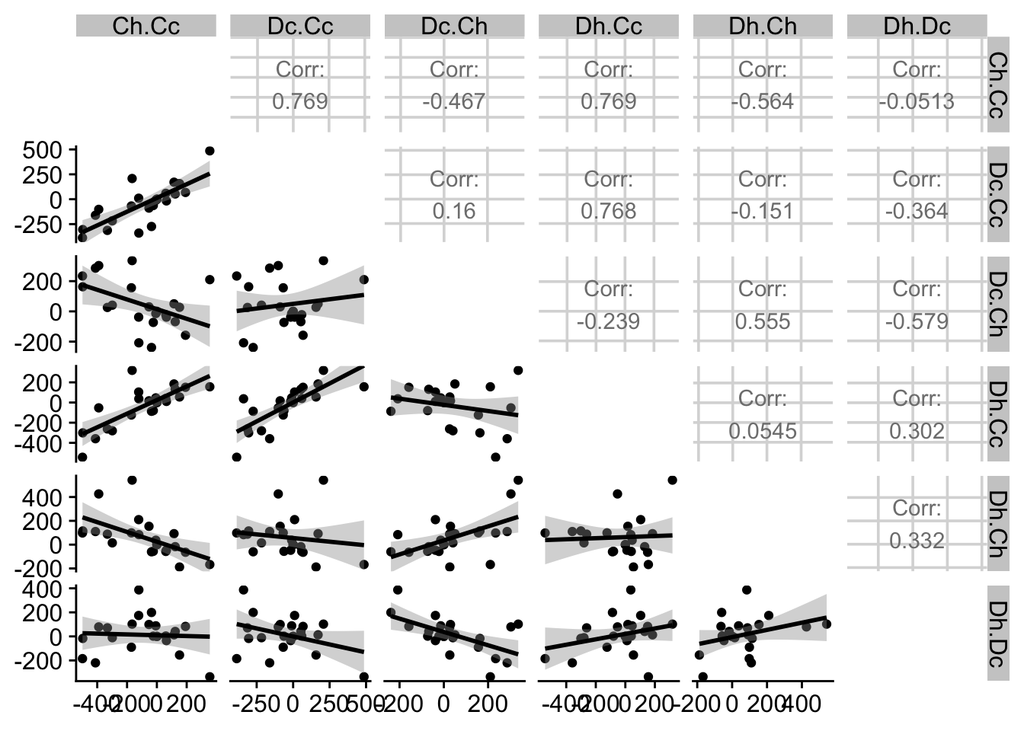

```r
# Visualize KOG response correlations between different contrasts
GGally::ggpairs(kogtable2, lower = list(continuous = "smooth"), diag = NULL)
```

```r
# Test whether correlation coefficients are greater than 0.5 (null hypothesis when comparing ratios with common denominator) or 0 (when ratios contain all different variables)
comparisons <- c("~ Ch.Cc + Dc.Cc", "~ Ch.Cc + Dc.Ch", "~ Ch.Cc + Dh.Cc", "~ Ch.Cc + Dh.Ch", "~ Ch.Cc + Dh.Dc",
                 "~ Dc.Cc + Dc.Ch", "~ Dc.Cc + Dh.Cc", "~ Dc.Cc + Dh.Ch", "~ Dc.Cc + Dh.Dc",
                 "~ Dc.Ch + Dh.Cc", "~ Dc.Ch + Dh.Ch", "~ Dc.Ch + Dh.Dc",
                 "~ Dh.Cc + Dh.Ch", "~ Dh.Cc + Dh.Dc",
                 "~ Dh.Ch + Dh.Dc")

tibble(comparison = comparisons) %>%
  mutate(cor = map(comparison, ~ cor.test(as.formula(.), data = kogtable2) %>% broom::tidy())) %>%
  unnest() %>%
  select(comparison, estimate, conf.low, conf.high) %>%
  mutate(samevars = map_lgl(comparison, ~ any(table(str_extract_all(., "C.|D.")) > 1)),
         nocor = pmap_lgl(list(samevars, conf.low, conf.high), function(x, y, z) {
           ifelse(x, !(y > 0.5 | z < -0.5), between(0, y, z))}))
```

```
## # A tibble: 15 x 6
##    comparison      estimate conf.low conf.high samevars nocor
##    <chr>              <dbl>    <dbl>     <dbl> <lgl>    <lgl>
##  1 ~ Ch.Cc + Dc.Cc   0.769    0.522     0.897  TRUE     FALSE
##  2 ~ Ch.Cc + Dc.Ch  -0.467   -0.737    -0.0676 TRUE     TRUE
##  3 ~ Ch.Cc + Dh.Cc   0.769    0.522     0.897  TRUE     FALSE
##  4 ~ Ch.Cc + Dh.Ch  -0.564   -0.792    -0.198  TRUE     TRUE
##  5 ~ Ch.Cc + Dh.Dc  -0.0513  -0.454     0.369  FALSE    TRUE
##  6 ~ Dc.Cc + Dc.Ch   0.160   -0.270     0.536  TRUE     TRUE
##  7 ~ Dc.Cc + Dh.Cc   0.768    0.521     0.896  TRUE     FALSE
##  8 ~ Dc.Cc + Dh.Ch  -0.151   -0.530     0.279  FALSE    TRUE
##  9 ~ Dc.Cc + Dh.Dc  -0.364   -0.675     0.0572 TRUE     TRUE
## 10 ~ Dc.Ch + Dh.Cc  -0.239   -0.593     0.192  FALSE    TRUE
## 11 ~ Dc.Ch + Dh.Ch   0.555    0.185     0.787  TRUE     TRUE
## 12 ~ Dc.Ch + Dh.Dc  -0.579   -0.800    -0.218  TRUE     TRUE
## 13 ~ Dh.Cc + Dh.Ch   0.0545  -0.366     0.456  TRUE     TRUE
## 14 ~ Dh.Cc + Dh.Dc   0.302   -0.126     0.635  TRUE     TRUE
## 15 ~ Dh.Ch + Dh.Dc   0.332   -0.0932    0.654  TRUE     TRUE
```

```r
# The 95% correlation coefficient for Ch.Cc and Dc.Cc does not contain 0.5 -- the expected correlation coefficient between the two ratios if the correlation between their numerators was zero.

# The correlation between Dc/Cc and Ch/Cc is 0.77. They have a common denominator so part of this correlation is due to that alone, although part is also due to an (unmeasurable) correlation between Dc and Ch. The correlation between Dc and Ch must be at least 0.5 (in the most conservative case that the correlation of both Dc and Ch with Cc is zero) (see Dunlap et al. 1997). Further evidence that Dc and Ch are correlated is that no KOG categories are significantly different in the comparison of Dc to Ch.
```

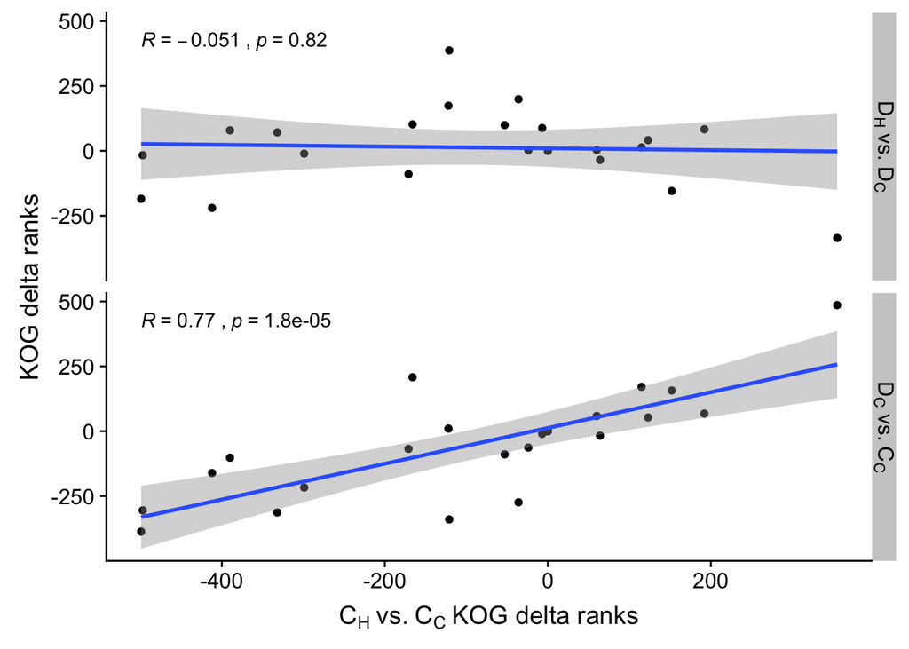

```r
# Figure showing KOG correlations between Dc.Cc and Ch.Cc, and lack of correlation between Dh.Dc and Ch.Cc.
kogtable2 %>%
  rownames_to_column("kog") %>%
  gather(contrast, value, -kog, -Ch.Cc) %>%
  filter(contrast %in% c("Dh.Dc", "Dc.Cc")) %>%
  mutate(contrast = factor(contrast, levels = c("Dh.Dc", "Dc.Cc"),
                           labels = c(expression("D"[H]~"vs."~"D"[C]), expression("D"[C]~"vs."~"C"[C])))) %>%
  ggplot(aes(x = Ch.Cc, y = value)) +
  facet_grid(contrast ~ ., labeller = "label_parsed") +
  geom_point() +
  geom_smooth(method = "lm") +
  stat_cor() +
  labs(x = expression("C"[H]~"vs."~"C"[C]~"KOG delta ranks"), y = "KOG delta ranks")
```

```r
ggsave(plot = last_plot(), filename = "figures/fig5.png", width = 80, height = 120, units = "mm")
```

Code archive

```r
df <- tibble(
  DcCcl2fc = DE$dsr[[3]]$log2FoldChange,
  ChCcl2fc = DE$dsr[[4]]$log2FoldChange,
  DhDcl2fc = DE$dsr[[1]]$log2FoldChange
)

ggplot(df, aes(x = ChCcl2fc, y = DcCcl2fc)) +
  geom_point() +
  geom_smooth(method = "lm") +
  stat_cor() +
  geom_abline(slope = 1)

ggplot(df, aes(x = ChCcl2fc, y = DhDcl2fc)) +
  geom_point() +
  geom_smooth(method = "lm") +
  stat_cor()

ggplot(df, aes(x = DhDcl2fc, y = -DcCcl2fc)) +
  geom_point() +
  geom_smooth(method = "lm") +
  stat_cor()

# Can we get normalized expression values instead of l2fc?
DE$dsr[[1]]
hs.dds
design(hs.dds)
results(hs.dds, contrast = )
df <- tibble(
  DcCcl2fc = DE$dsr[[3]]$log2FoldChange,
  ChCcl2fc = DE$dsr[[4]]$log2FoldChange,
  DhDcl2fc = DE$dsr[[1]]$log2FoldChange
)
```

```r
# logic: if shuffling to D produces a response similar to heat stress in C
###  e.g., Dc vs. Cc is similar to Ch. vs. Cc
# does: shuffling to C produce a response similar to heat stress in D
###  is    Cc vs. Dc similar to Dh vs. Dc?
ggplot(df, aes(x = DhDcl2fc, y = -DcCcl2fc)) +
  geom_point() +
  geom_smooth(method = "lm") +
  stat_cor() +
  geom_abline(slope = 1)
## yes.... this seems to undermine the entire story....?

### But---is this artifact of using all genes?
## If look at KOG delta ranks, it's not significant... (NEED TO CONFIRM THIS)




# maker random numbers
df <- tibble(
  n1 = runif(20),
  n2 = runif(20),
  n3 = n2 + runif(20),
   d = runif(20)
)

ggplot(df, aes(x = log(n1/d), y = log(n2/d))) +
  geom_point() +
  geom_smooth(method = "lm") +
  stat_cor() +
  geom_abline(slope =1, intercept = 0)

ggplot(df, aes(x = n2, y = n3)) + geom_point()

#### NEED TO TEST WHETHER R > 0.5.... 0.5 expected with common denominator for random data!!!
```

```r
setwd("code/GO_MWU")
#source("gomwu.functions.R")

# Write colony 26 D-control vs. C-control logP values to file for GO_MWU analysis
DE %>%
  filter(colony == "26", num == "Dc", den == "Cc") %>%
  unnest(logP) %>%
  select(gene, logP) %>%
  write.table(., file = "26.Dctrl.Cctrl.logP.txt", row.names = FALSE, quote = FALSE, sep = ",")

# Run GO_MWU for colony 26 D-control vs. C-contol for Biological Process (BP) GO terms
commandArgs <- function(...) c("26.Dctrl.Cctrl.logP.txt", "BP")
source("GO_MWU.R")

# Plot GO_MWU results for colony 26 D-control vs. C-contol for Biological Process (BP) GO terms
#png(filename = "../../figures/26.Dheat.Dctrl.DE.GO.png", width = 140, height = 60, units = "mm", res = 300)
par(xpd = NA)
resultsBP <- gomwuPlot(inFile = "26.Dctrl.Cctrl.logP.txt",
                       goAnnotations = "Mcavernosa_gene2go.txt",
                       goDivision = "BP",
                       level1 = 0.25, level2 = 0.1, level3 = 0.01, txtsize = 1.2, treeHeight = 0.5)
#dev.off()
```

```r
# WGCNA

library(WGCNA)  # BiocManager::install("WGCNA")

# Get only genes that are DE in any contrast
DEgenes <- DE %>%
  unnest(sig) %>%
  distinct(gene)

DEvsd <- assay(vsd)[DEgenes$gene, ]

# Choose a set of soft-thresholding powers
powers = c(c(1:15))
# Call the network topology analysis function
sft = pickSoftThreshold(t(DEvsd), powerVector = powers, verbose = 5)
# Plot the results:
par(mfrow = c(1,2));
cex1 = 0.9;
# Scale-free topology fit index as a function of the soft-thresholding power
plot(sft$fitIndices[,1], -sign(sft$fitIndices[,3])*sft$fitIndices[,2],
xlab="Soft Threshold (power)",ylab="Scale Free Topology Model Fit,signed R^2",type="n",
main = paste("Scale independence"));
text(sft$fitIndices[,1], -sign(sft$fitIndices[,3])*sft$fitIndices[,2],
labels=powers,cex=cex1,col="red");
# this line corresponds to using an R^2 cut-off of h
abline(h=0.90,col="red")
# Mean connectivity as a function of the soft-thresholding power
plot(sft$fitIndices[,1], sft$fitIndices[,5],
xlab="Soft Threshold (power)",ylab="Mean Connectivity", type="n",
main = paste("Mean connectivity"))
text(sft$fitIndices[,1], sft$fitIndices[,5], labels=powers, cex=cex1,col="red")




net = blockwiseModules(t(DEvsd), power = 7,
                       TOMType = "unsigned", minModuleSize = 15,
                       reassignThreshold = 0, mergeCutHeight = 0.25,
                       numericLabels = TRUE, pamRespectsDendro = FALSE,
                       saveTOMs = TRUE,
                       saveTOMFileBase = "femaleMouseTOM",
                       verbose = 3)

table(net$colors)

# Convert labels to colors for plotting
mergedColors = labels2colors(net$colors)
# Plot the dendrogram and the module colors underneath
plotDendroAndColors(net$dendrograms[[1]], mergedColors[net$blockGenes[[1]]],
                    "Module colors",
                    dendroLabels = FALSE, hang = 0.03,
                    addGuide = TRUE, guideHang = 0.05)

eigen <- net$MEs

pheatmap(t(net$MEs), labels_col = sdat$group[match(rownames(net$MEs), rownames(sdat))])
```

```r
##### PCoA with only DE genes

# Get only genes that are DE across all colonies
DEgenes <- DE %>%
  filter(colony == "all") %>%
  unnest(sig) %>%
  distinct(gene)

# Get variance stabilized counts for DE genes
DEvsd <- vsd[DEgenes$gene, ]
# Remove 'batch' effect of colony
assay(DEvsd) <- limma::removeBatchEffect(assay(DEvsd), DEvsd$colony)

## Calculate distances among samples
DEsampleDists <- dist(t(assay(DEvsd)), method = "euclidean")
DEsampleDistMatrix <- as.matrix(DEsampleDists)

## Calculate MDS
DEmds <- as.data.frame(colData(DEvsd)) %>% cbind(cmdscale(DEsampleDistMatrix))

# Calculate group centroids for plotting
DEmds <- DEmds %>%
  group_by(sym, trt2) %>%
  summarise(c1 = mean(`1`), c2 = mean(`2`)) %>%
  full_join(DEmds)

# Plot with spiders
DEpcoa <- ggplot(DEmds, aes(color = sym:trt2)) +
  geom_segment(mapping = aes(x = `1`, y = `2`, xend = c1, yend = c2),
               lwd = 0.25, col = "grey") +
  geom_point(aes(x = c1, y = c2), size = 5, alpha = 1) +
  geom_point(aes(x = `1`, y = `2`), alpha = 1) +
  labs(x = "PC1", y = "PC2")

DEpcoa # + geom_text(aes(x = `1`, y = `2`, label = paste(colony, core)))
```

```r
# DA Loadings
### Find genes that load highly along axis 1 -- the one associated with general heat stress and presence of D
contrib <- loadingplot(dp1$var.contr, axis=1, thres=.003, lab.jitter=1)
### Plot counts of those genes
plotCounts(hs.dds, gene = "Mcavernosa19950", intgroup = c("group"))

plotCounts(hs.dds, gene = "Mcavernosa19950", intgroup = c("group"), returnData = TRUE)




### Find genes that load highly along axis 2 -- the one associated with unique heat response of C vs. D
contrib <- loadingplot(dp1$var.contr, axis=2, thres=.003, lab.jitter=1)
### Plot counts of those genes
plotCounts(hs.dds, gene = "Mcavernosa05569", intgroup = c("group"))
plotCounts(hs.dds, gene = "Mcavernosa18398", intgroup = c("group"))
plotCounts(hs.dds, gene = "Mcavernosa25590", intgroup = c("group"))
plotCounts(hs.dds, gene = "Mcavernosa21308", intgroup = c("group"))
```